### CS 4840 Applied Machine Learning - Lab Assignment 3

# Random Forest and Neural Networks

### 1. Overview

An ensemble of decision tree is called random forest. Despite its simplicity, this is one of the most powerful shallow learning algorithms available today. Neural networks are at very core of deep learning, which are versatile, powerful, and scalable, making them ideal to tackle large and highly complex machine learning tasks. The learning objective of this lab assignment is for students to understand random forest and neural networks, including how to train these models with the impacts of key parameters, how to evaluate their classification performances, and how to compare these results among different classification models.

#### Lecture notes.

Detailed coverage of these topics can be found in the following:

Ensemble Learning

Neural Networks

#### Code demonstrations.

Code 2023-10-30-M-Ensemble Learning and Random Forest.ipynb

Code 2023-11-15-W-Neural Networks.ipynb

### 2. Submission

You need to submit a detailed lab report with code, running results, and answers to the questions. If you submit a jupyter notebook (“Firstname-Lastname-4840-Lab3.ipynd”), please fill in this file directly and place the code, running results, and answers in order for each question. If you submit a PDF report (“Firstname-Lastname-4840-Lab3.pdf”) with code file (“Firstname-Lastname-4840-Lab3.py”), please include the screenshots (code and running results) with answers for each question in the report.

### 3. Questions (50 points)

For this lab assignment, you will be using the `MNIST dataset` to complete the following tasks and answer the questions. The MNIST dataset is a set of 70,000 small images of digits handwritten by high school students and employees of the US Census Bureau. Each image is labeled with the digit it represents. You will use these features to build random forest and deep neural network models to predict the `digit` of an image. First, please place load the data.

#### Load and plot the data

Loading MNIST data of 70,000 images may take some time.

```python
from sklearn.datasets import fetch_openml

mnist = fetch_openml('mnist_784', version=1, as_frame=False, parser='auto')
X, y = mnist["data"], mnist["target"]
```

```python
print(X.shape, y.shape)
print(X)
```

```
(70000, 784) (70000,)
[[0. 0. 0. ... 0. 0. 0.]
 [0. 0. 0. ... 0. 0. 0.]
 [0. 0. 0. ... 0. 0. 0.]
 ...
 [0. 0. 0. ... 0. 0. 0.]
 [0. 0. 0. ... 0. 0. 0.]
 [0. 0. 0. ... 0. 0. 0.]]
```

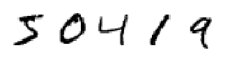

```python
import numpy as np
import matplotlib as mpl
import matplotlib.pyplot as plt

# Plot the data
def plot_digits(instances, images_per_row=5, **options):
    size = 28
    images_per_row = min(len(instances), images_per_row)
    n_rows = (len(instances) - 1) // images_per_row + 1
    n_empty = n_rows * images_per_row - len(instances)
    padded_instances = np.concatenate([instances, np.zeros((n_empty, size * size))], axis=0)

    # Reshape the array so it's organized as a grid containing 28×28 images:
    image_grid = padded_instances.reshape((n_rows, images_per_row, size, size))
    big_image = image_grid.transpose(0, 2, 1, 3).reshape(n_rows * size,
                                                         images_per_row * size)

    # Now that we have a big image, we just need to show it:
    plt.imshow(big_image, cmap = mpl.cm.binary, **options)
    plt.axis("off")

plt.figure(figsize=(4,4))
example_images = X[:5]  #select the first 25 elements from the array X
plot_digits(example_images, images_per_row=5)
plt.show()
```

```python
# X[:60000] takes the first 60,000 entries from the X array
# X[60000:] takes all entries from the X array starting from the 60,001st entry to the end
X_train, X_test, y_train, y_test = X[:60000], X[60000:], y[:60000], y[60000:]
```

**About the data used in this assignment:**  
**The MNIST dataset is actually already split into a training set (the first 60,000 images) and a test set (the last 10,000 images). All the classification models in this lab are trained on `X_train`, `y_train`, and evaluated on `X_test`, `y_test`.**

#### Question 1 (14 points):

Please train a random forest model using **random patches** in function `answer_one( )`. Random patches is to sample training instances for each decision tree with or without replacement, which can be implemented using bagging ensemble method `BaggingClassifier` over a number of decision trees `DecisionTreeClassifier`; each tree is built upon a subset of training instances. After the random forest is trained, evaluate the performance, including accuracy, micro F1 score, and macro F1 score.

**Set `DecisionTreeClassifier()`, `n_estimators=100`, `bootstrap=True` and `random_state=42` in `BaggingClassifier` to formulate random forest through a number of decision trees**

**Adjust the option `max_samples=` in `BaggingClassifier` to set the size for each subset of training instances as `1,000`, `2,000` and `3,000`**

```python
import time
from sklearn.ensemble import BaggingClassifier
from sklearn.tree import DecisionTreeClassifier
from sklearn.metrics import accuracy_score, f1_score

# creates and trains three different Random Forest models
# using the Random Patches method, with a different max_samples value
def answer_one(X_train, y_train, X_test, y_test):

    max_samples_values = [1000, 2000, 3000]

    # Initialize results
    results = []

    for max_samples in max_samples_values:
        start_time = time.time()

        random_patches = BaggingClassifier(estimator=DecisionTreeClassifier(),
                                           n_estimators=100,     # Number of trees
                                           bootstrap=True,       # Samples are drawn with replacement
                                           max_samples=max_samples,  # Number of samples per base estimator
                                           random_state=42)

        random_patches.fit(X_train, y_train)

        y_pred = random_patches.predict(X_test)

        accuracy = accuracy_score(y_test, y_pred)
        micro_f1 = f1_score(y_test, y_pred, average='micro')
        macro_f1 = f1_score(y_test, y_pred, average='macro')

        # End timing
        end_time = time.time()
        training_time = end_time - start_time

        results.append((max_samples,accuracy, micro_f1, macro_f1,training_time))

    return results

results = answer_one(X_train, y_train, X_test, y_test)

# Display results
for max_samples, accuracy, micro_f1, macro_f1, training_time in results:
    print(f"Results for max_samples={max_samples}: Accuracy={accuracy}, Micro F1={micro_f1}, Macro F1={macro_f1}, Training Time={training_time} seconds")
```

```
Results for max_samples=1000: Accuracy=0.9086, Micro F1=0.9086, Macro F1=0.9071503236075781, Training Time=63.3993775844574 seconds
Results for max_samples=2000: Accuracy=0.9249, Micro F1=0.9249, Macro F1=0.9238682068426549, Training Time=93.99083018302917 seconds
Results for max_samples=3000: Accuracy=0.9313, Micro F1=0.9312999999999999, Macro F1=0.9303511086446108, Training Time=144.23957204818726 seconds
```

#### Answer 1:

Report the performance and time used by three training subset sizes of 1,000, 2,000, and 3,000:  
**`max_samples=1000`**: Accuracy is: ( 0.9086 ), Micro f1 score is: ( 0.9086 ), Macro f1 score is: (0.90715 ), Time used: ( 63.4)  
**`max_samples=2000`**: Accuracy is: ( 0.9249 ), Micro f1 score is: ( 0.9249 ), Macro f1 score is: ( 0.92386 ), Time used: ( 93.990)  
**`max_samples=3000`**: Accuracy is: ( 0.9313 ), Micro f1 score is: ( 0.931 ), Macro f1 score is: ( 0.93035 ), Time used: (144.23)

#### Question 2 (14 points):

Please train a random forest model using **random subspaces** in function `answer_two( )`. Random subspaces is to sample training features while keeping all training instances for each decision tree, which can be implemented using bagging ensemble method `BaggingClassifier` over a number of decision trees `DecisionTreeClassifier`; each tree is built upon a subset of training features. After the random forest is trained, evaluate the performance, including accuracy, micro F1 score, and macro F1 score.

**Set `DecisionTreeClassifier()`, `n_estimators=100` and `random_state=42` in `BaggingClassifier` to formulate random forest through a number of decision trees**

**Adjust the option `max_features=` in `BaggingClassifier` to set the size for each subset of features as `10`, `30` and `50`**

```python
from sklearn.ensemble import BaggingClassifier
from sklearn.tree import DecisionTreeClassifier
from sklearn.metrics import accuracy_score, f1_score
import time

def answer_two(X_train, y_train, X_test, y_test):
    # Define the list of max_features values
    max_features_values = [10, 30, 50]

    # Store results
    results = []

    for max_features in max_features_values:
        # Start timing
        start_time = time.time()

        # Create a Bagging Classifier with DecisionTreeClassifier as the base
        model = BaggingClassifier(estimator=DecisionTreeClassifier(),
                                  n_estimators=100,
                                  max_features=max_features,
                                  random_state=42)

        # Train the model
        model.fit(X_train, y_train)

        # Evaluate the model
        y_pred = model.predict(X_test)
        accuracy = accuracy_score(y_test, y_pred)
        micro_f1 = f1_score(y_test, y_pred, average='micro')
        macro_f1 = f1_score(y_test, y_pred, average='macro')

        # End timing
        end_time = time.time()
        training_time = end_time - start_time

        results.append((max_features, accuracy, micro_f1, macro_f1, training_time))

    return results

# Run the function
results = answer_two(X_train, y_train, X_test, y_test)

# Display results
for max_features, accuracy, micro_f1, macro_f1, training_time in results:
    print(f"Results for max_features={max_features}: Accuracy={accuracy}, Micro F1={micro_f1}, Macro F1={macro_f1}, Training Time={training_time} seconds")
```

```
Results for max_features=10: Accuracy=0.8442, Micro F1=0.8442, Macro F1=0.8396407876948139, Training Time=27.64089322090149 seconds
Results for max_features=30: Accuracy=0.9489, Micro F1=0.9489, Macro F1=0.9485003601303079, Training Time=75.42722964286804 seconds
Results for max_features=50: Accuracy=0.9628, Micro F1=0.9628, Macro F1=0.9625549245988667, Training Time=148.65850377082825 seconds
```

#### Question 3 (7 points):

**Double click here to answer the questions in this cell:**  
In Question 1, random forest uses random subset of training instances with all features for each decision tree. In Question 2, random forest randomly samples a very small subset of features while keeping all training instances for each decision tree. Both random forests have 100 decision trees. Please **compare the best results of these two models**:

#### Install Tensorflow and Keras

You need to use Keras to build neural networks in the next question. As Keras has been integrated into Tensorflow package, please install Tensorflow (version ≥2.0 is required) as follows if you havn't done so yet:

**`python3 -m pip install --upgrade tensorflow`**

```python
# TensorFlow ≥2.0 is required
import tensorflow as tf
assert tf.__version__ >= "2.0", "The version of Tensorflow needs to be ≥2.0"

print(tf.__version__)
print("The version of Tensorflow you installed is ≥2.0")
```

```
2.13.1
The version of Tensorflow you installed is ≥2.0
```

#### Preprocess MNIST

```python
X_train, X_test = X_train / 255., X_test / 255.

y_train, y_test = y_train.astype(np.uint8), y_test.astype(np.uint8)
```

#### Question 4 (15 points):

Please train a multi-layer perceptron in function `answer_four( )`. After the neural network is trained, evaluate the test loss and accuracy.

**Set dropout rate in `keras.layers.Dropout()` as `0.3`, `0.5` and `0.7` respectively to compare the different performance**

```python
import tensorflow as tf
from tensorflow import keras

tf.random.set_seed(42)

def answer_four(dropout_rate):
    model = keras.models.Sequential([
        keras.layers.Input(shape=(784,)),
        keras.layers.Dense(300, activation='relu'),
        keras.layers.Dropout(dropout_rate),
        keras.layers.Dense(100, activation='relu'),
        keras.layers.Dropout(dropout_rate),
        keras.layers.Dense(10, activation='softmax')
    ])

    model.compile(
        loss='sparse_categorical_crossentropy',
        optimizer='adam',
        metrics=['accuracy']
    )

    model.fit(X_train, y_train, epochs=30, batch_size=64, validation_data=(X_test, y_test))

    loss, accuracy_4 = model.evaluate(X_test, y_test)

    return loss, accuracy_4

# Example usage:
dropout_rates = [0.3, 0.5, 0.7]
results = {}
for rate in dropout_rates:
    loss, accuracy_4 = answer_four(rate)
    results[rate] = (loss, accuracy_4)

# Results will contain loss and accuracy for each dropout rate
print(results)
```

```
2023-12-10 23:50:20.837633: W tensorflow/tsl/framework/cpu_allocator_impl.cc:83] Allocation of 188160000 exceeds 10% of free system memory.
```

```
2023-12-10 23:54:30.800801: W tensorflow/tsl/framework/cpu_allocator_impl.cc:83] Allocation of 188160000 exceeds 10% of free system memory.
```

```
2023-12-10 23:58:45.351056: W tensorflow/tsl/framework/cpu_allocator_impl.cc:83] Allocation of 188160000 exceeds 10% of free system memory.
```

```
{0.3: (0.07449394464492798, 0.9771000146865845), 0.5: (0.08820629119873047, 0.9732000231742859), 0.7: (0.15019303560256958, 0.957099974155426)}
```

#### Answer 4:

Report the performance by three dropout rate of 0.3, 0.5, and 0.7:  
**`keras.layers.Dropout(0.3)`**: Test loss is: ( 0.074 ), Test accuracy is: ( 0.9771 )  
**`keras.layers.Dropout(0.5)`**: Test loss is: ( 0.0882 ), Test accuracy is: ( 0.973 )  
**`keras.layers.Dropout(0.7)`**: Test loss is: ( 0.15019), Test accuracy is: ( 0.957 )

Based on the best performance of multi-layer perceptron (neural networks) and the best performance of random forest, which model outperforms the other one: ( ), and explain why: ( ) neural networks is better.MLP is good for large datasets,high dimensional and complex problems like image and speech recognition.